# Module 7 HW - Question 1

# Module 7 HW - Question 2.a

What is the distance between the two farthest members (Complete-link) (round to four decimal places here, and next 2 problems)?

In order to determine the two farthest members by calculating the complete-link distance, we will need to calculate the pairwise euclidean distances, using np.linalg.norm which will calculate the pairwise between the two clusters. From there, we will get the maximum distance and the pair of points who make up this max difference.

```python
# Calculate all pairwise distances between points in cluster A and B
all_pairwise_distances = np.linalg.norm(cluster_A_points[:, np.newaxis] - cluster_B_points, axis=2)

# Find the minimum distance (the single-linkage distance)
complete_link_distance = np.max(all_pairwise_distances)

# Get the indices of the closest members
max_distance_indices = np.where(all_pairwise_distances == complete_link_distance)

# Extract the members that have the single link distance
farthest_members_A = cluster_A_points[max_distance_indices[0]]
farthest_members_B = cluster_B_points[max_distance_indices[1]]

complete_link_distance, farthest_members_A, farthest_members_B
print(f'max distance (complete-link distance): {round(complete_link_distance, 2)}\nfarthest points: {farthest_members_A, farthest_members_B}')
```

```
max distance (complete-link distance): 2.11
farthest points: (array([[4.6, 2.9]]), array([[6.7, 3.1]]))
```

# Module 7 HW - Question 2.b

What is the distance between the two closest members (Single-link)?

We've already calculated the pairwise distances, we will need to just use the same methods to extract the min distances of the pairwise euclidean distances.

```python
# Find the minimum distance (the single-linkage distance)
single_link_distance = np.min(all_pairwise_distances)

# Get the indices of the closest members
min_distance_indices = np.where(all_pairwise_distances == single_link_distance)

# Extract the members that have the single link distance
closest_members_A = cluster_A_points[min_distance_indices[0]]
closest_members_B = cluster_B_points[min_distance_indices[1]]

single_link_distance, closest_members_A, closest_members_B
print(f'min distance (single-link distance): {round(single_link_distance, 2)}\nfarthest points: {closest_members_A, closest_members_B}')
```

```
min distance (single-link distance): 0.95
farthest points: (array([[5. , 2.9]]), array([[5.9, 3.2]]))
```

# Module 7 HW - Question 2.c

What is the average distance between all pairs (Average-link)?

Here, rather than get the min or max, we will get the mean of all pairwise euclidean distances.

```python
# Find the minimum distance (the single-linkage distance)
average_link_distance = np.mean(all_pairwise_distances)
print(f'mean distance (average-link distance): {round(average_link_distance, 2)}')
```

```
mean distance (average-link distance): 1.41
```

# Module 7 HW - Question 2.d

Among all three distances above, which one is robust to noise?

- Complete-Link is the most robust to noise. Due to it's measures of defining clusters as the furthest neighbor between any group of points between clusters it results in clustering to those points who are relatively close to one another in order for them to be merged. This causes a reduction of influence from outliers and noise causing more tightly bound clusters.

# Module 7 HW - Question 3

Fill out the code cells in hw_7.ipynb and answer the questions.

# Unsupervised Learning - Clustering

We've shown several unsupervised learning algorithms in this unit, We first introduced the simplest clustering algorihtm k-means. Hierarchical clustering included agglomerative and divisive clustering algorithms. Finally we discussed a powerful density-based algorihtm DBSCAN that performs fairly well when the clusters have irregular shapes, In this coding assignment you will explore more clustering algorithms and become familiar with the sklearn's clustering package. You'll also need to tune the hyper parameters of these models and get a sense about how the hyperparameters influence the shape of resulting clusters.

## Loading the Dataset

Load dataset with different cluster shapes and try algorithms on them.

```python
from sklearn.datasets import make_blobs, make_moons, make_circles, make_swiss_roll
import matplotlib.pyplot as plt
import numpy as np
from sklearn.cluster import KMeans, AgglomerativeClustering, DBSCAN
from sklearn.preprocessing import StandardScaler
from sklearn import metrics
import time
import warnings
```

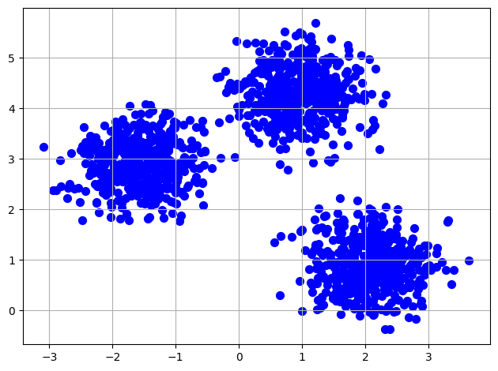

```python
n_samples = 1500
X_blobs, y_blobs = make_blobs(n_samples= n_samples,
                  n_features=2,
                  centers=3,
                  cluster_std=0.5,
                  shuffle=True,
                  random_state=0)
plt.scatter(X_blobs[:, 0], X_blobs[:, 1], c='blue', marker='o', s=50)
plt.grid()
plt.tight_layout()
plt.show()
```

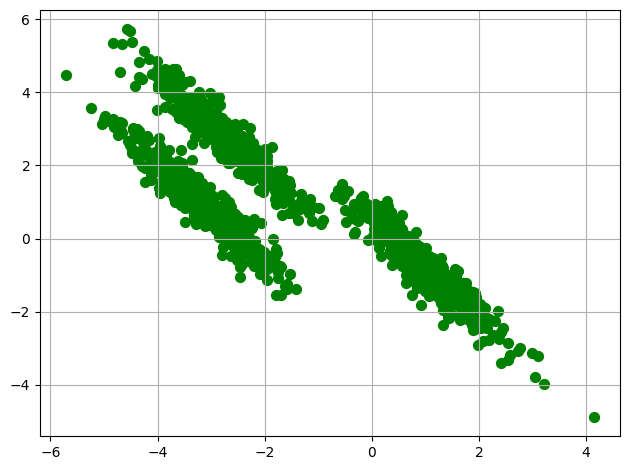

```python
random_state = 170
X_blobs1, y_blobs1 = make_blobs(n_samples=n_samples, random_state=random_state)
transformation = [[0.6, -0.6], [-0.4, 0.8]]
X_aniso = np.dot(X_blobs1, transformation)
aniso = (X_aniso, y_blobs1)
plt.scatter(aniso[0][:, 0], aniso[0][:, 1], c='green', marker='o', s=50)
plt.grid()
plt.tight_layout()
plt.show()
```

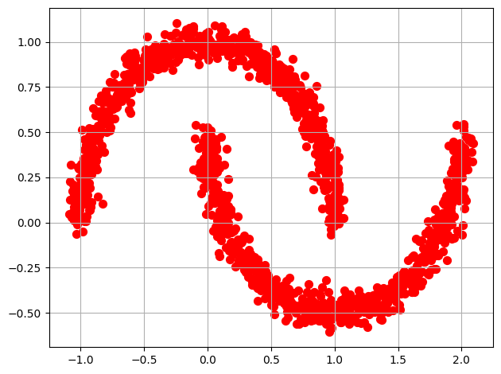

```python
noisy_moons = make_moons(n_samples=n_samples, noise=.05)
plt.scatter(noisy_moons[0][:, 0], noisy_moons[0][:, 1], c='red', marker='o', s=50)
plt.grid()
plt.tight_layout()
plt.show()
```

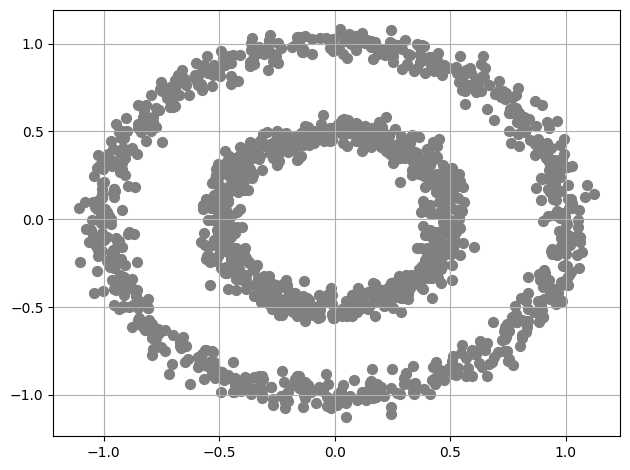

```python
noisy_circles = make_circles(n_samples=n_samples, factor=.5,
                                      noise=.05)
plt.scatter(noisy_circles[0][:, 0], noisy_circles[0][:, 1], c='grey', marker='o', s=50)
plt.grid()
plt.tight_layout()
plt.show()
```

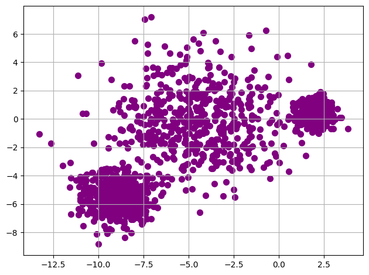

```python
varied = make_blobs(n_samples=n_samples,
                             cluster_std=[1.0, 2.5, 0.5],
                             random_state=random_state)
plt.scatter(varied[0][:, 0], varied[0][:, 1], c='purple', marker='o', s=50)
plt.grid()
plt.tight_layout()
plt.show()
```

## Grouping objects by similarity using k-means

K-means algorithm is simple but it performs poorly to enlongated clusters, or manifolds with irregular shapes.

```python
def print_cluster(model, n_clusters, X):
    y_km = model.fit_predict(X)
    color_list = ['lightgreen', 'orange', 'lightblue', 'red', 'yellow', 'brown', 'cyan']
    for i in range(n_clusters):
        plt.scatter(X[y_km == i, 0],
        X[y_km == i, 1],
        s=50,
        c=color_list[i],
        marker='s',
        label='cluster ' + str(i))
    plt.legend()
    plt.grid()
    plt.tight_layout()
    plt.show()
```

```python
km = KMeans(n_clusters=3,
            init='random',
            n_init=10,
            max_iter=300,
            tol=1e-04,
            random_state=0)
```

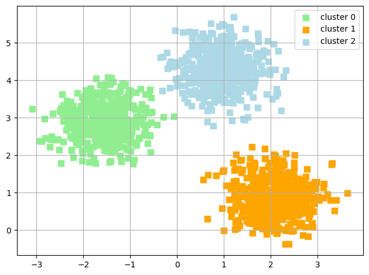

```python
print_cluster(km, 3, X_blobs)
```

## Using the elbow method to find the optimal number of clusters

```python
def plot_distortions(data):
    distortions = []
    for i in range(1, 11):
        km = KMeans(n_clusters=i,
                init='k-means++',
                n_init=10,
                max_iter=300,
                random_state=0)
        km.fit(data)
        distortions.append(km.inertia_)
    plt.plot(range(1, 11), distortions, marker='o')
    plt.xlabel('Number of clusters')
    plt.ylabel('Distortion')
    plt.tight_layout()
    plt.show()
```

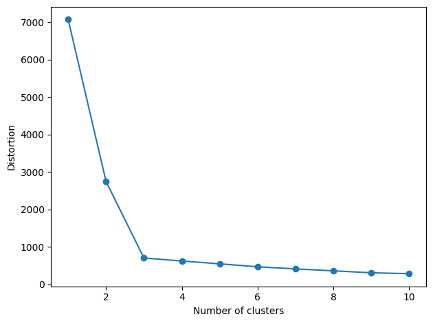

```python
plot_distortions(X_blobs) # select k=3
```

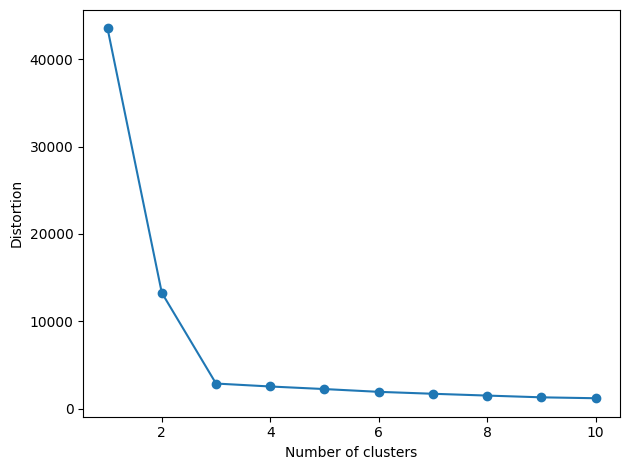

```python
# TODO :: run the kmeans on the other datasets and use elbow method to select the number of clusters.

plot_distortions(X_blobs1) # select k=3
```

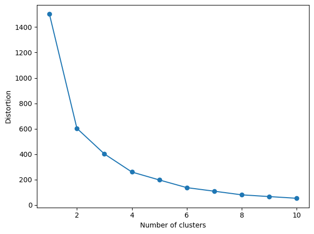

```python
plot_distortions(noisy_moons[0]) # k value is more difficult to distnguish, choose k=4
```

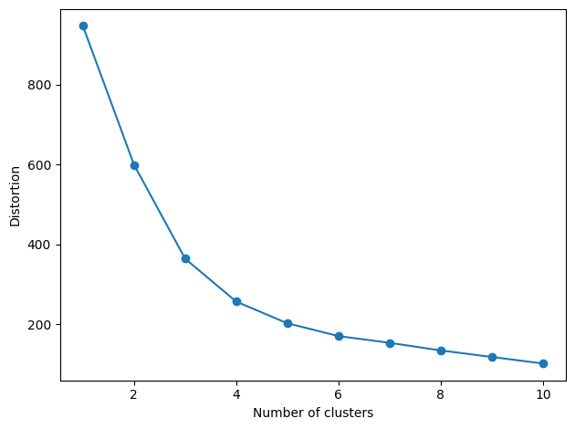

```python
plot_distortions(noisy_circles[0]) # k value is more difficult to distnguish, choose k=4
```

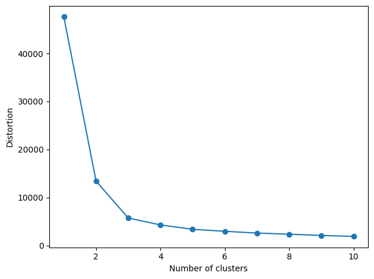

```python
plot_distortions(varied[0]) # select k=3
```

## Hierarchical clustering

Hierarchical clustering is a general family of clustering algorithms that build nested clusters by merging or splitting them successively. This hierarchy of clusters is represented as a tree (or dendrogram). The root of the tree is the unique cluster that gathers all the samples, the leaves being the clusters with only one sample.

## Agglomerative Clustering

The algorithm performs a hierarchical clustering using a bottom up approach. Agglomerative cluster has a “rich get richer” behavior that leads to uneven cluster sizes.

[output not shown]

[output cut: 15 more lines]

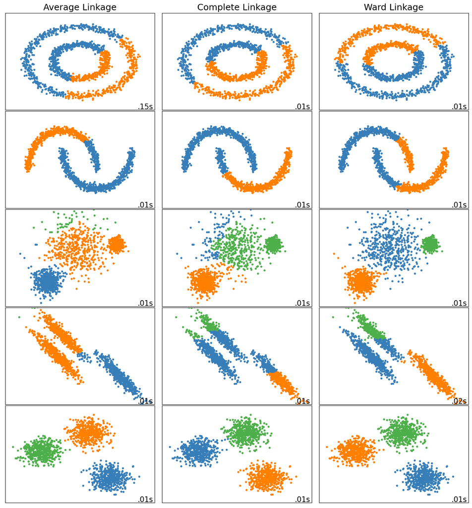

```python
from itertools import cycle, islice

# Set up cluster parameters
plt.figure(figsize=(9 * 1.3 + 2, 14.5))
plt.subplots_adjust(left=.02, right=.98, bottom=.001, top=.96, wspace=.05,
                    hspace=.01)

plot_num = 1

default_base = {'n_neighbors': 10,
                'n_clusters': 3}

datasets = [
    (noisy_circles, {'n_clusters': 2}),
    (noisy_moons, {'n_clusters': 2}),
    (varied, {'n_neighbors': 2}),
    (aniso, {'n_neighbors': 2}),
    ((X_blobs, y_blobs), {})]

for i_dataset, (dataset, algo_params) in enumerate(datasets):
    # update parameters with dataset-specific values
    params = default_base.copy()
    params.update(algo_params)

    X, y = dataset

    # normalize dataset for easier parameter selection
    X = StandardScaler().fit_transform(X)

    # ============
    # Create cluster objects
    # ============
    ward = AgglomerativeClustering(
        n_clusters=params['n_clusters'], linkage='ward')
    complete = AgglomerativeClustering(
        n_clusters=params['n_clusters'], linkage='complete')
    average = AgglomerativeClustering(
        n_clusters=params['n_clusters'], linkage='average')

    clustering_algorithms = (
        ('Average Linkage', average),
        ('Complete Linkage', complete),
        ('Ward Linkage', ward),
    )

    for name, algorithm in clustering_algorithms:
        t0 = time.time()

        # catch warnings related to kneighbors_graph
        with warnings.catch_warnings():
            warnings.filterwarnings(
                "ignore",
                message="the number of connected components of the " +
                "connectivity matrix is [0-9]{1,2}" +
                " > 1. Completing it to avoid stopping the tree early.",
                category=UserWarning)
            algorithm.fit(X)

        t1 = time.time()
        if hasattr(algorithm, 'labels_'):
            y_pred = algorithm.labels_.astype(np.int)
        else:
            y_pred = algorithm.predict(X)

        plt.subplot(len(datasets), len(clustering_algorithms), plot_num)
        if i_dataset == 0:
            plt.title(name, size=18)

        colors = np.array(list(islice(cycle(['#377eb8', '#ff7f00', '#4daf4a',
                                             '#f781bf', '#a65628', '#984ea3',
                                             '#999999', '#e41a1c', '#dede00']),
                                      int(max(y_pred) + 1))))
        plt.scatter(X[:, 0], X[:, 1], s=10, color=colors[y_pred])

        plt.xlim(-2.5, 2.5)
        plt.ylim(-2.5, 2.5)
        plt.xticks(())
        plt.yticks(())
        plt.text(.99, .01, ('%.2fs' % (t1 - t0)).lstrip('0'),
                 transform=plt.gca().transAxes, size=15,
                 horizontalalignment='right')
        plot_num += 1

plt.show()
```

```
Compute structured hierarchical clustering...
Elapsed time: 0.008779048919677734
Compute structured hierarchical clustering...
Elapsed time: 0.02070307731628418
```

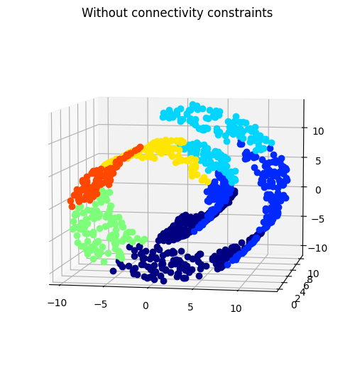

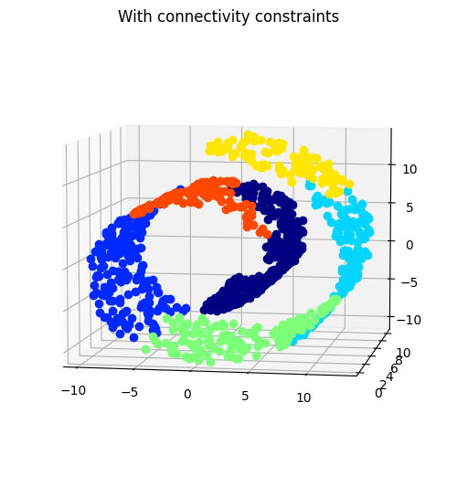

```python
import time as time
import numpy as np
import pylab as pl
import mpl_toolkits.mplot3d.axes3d as p3

###############################################################################
# Generate data (swiss roll dataset)
n_samples = 1000
noise = 0.05
X, _ = make_swiss_roll(n_samples=n_samples, noise=noise)
# Make it thinner
X[:, 1] *= .5

###############################################################################
# Compute clustering
print("Compute structured hierarchical clustering...")
st = time.time()
ward = AgglomerativeClustering(
        n_clusters=6, linkage='ward')
ward.fit(X)
if hasattr(algorithm, 'labels_'):
    label = ward.labels_.astype(np.int)
else:
    label = ward.predict(X)
print ("Elapsed time: {}".format(time.time() - st))

###############################################################################
# Plot result
fig = pl.figure()
ax = p3.Axes3D(fig)
ax.view_init(7, -80)
for l in np.unique(label):
    ax.plot3D(X[label == l, 0], X[label == l, 1], X[label == l, 2],
              'o', color=pl.cm.jet(np.float(l) / np.max(label + 1)))
pl.title('Without connectivity constraints')

###############################################################################
# Define the structure A of the data. Here a 10 nearest neighbors
from sklearn.neighbors import kneighbors_graph
connectivity = kneighbors_graph(X, n_neighbors=10)

###############################################################################
# Compute clustering
print("Compute structured hierarchical clustering...")
st = time.time()
ward = AgglomerativeClustering(
        n_clusters=6, linkage='ward', connectivity=connectivity)
ward.fit(X)
if hasattr(algorithm, 'labels_'):
    label = ward.labels_.astype(np.int)
else:
    label = ward.predict(X)
print ("Elapsed time: {}".format(time.time() - st))

###############################################################################
# Plot result
fig = pl.figure()
ax = p3.Axes3D(fig)
ax.view_init(7, -80)
for l in np.unique(label):
    ax.plot3D(X[label == l, 0], X[label == l, 1], X[label == l, 2],
              'o', color=pl.cm.jet(float(l) / np.max(label + 1)))
pl.title('With connectivity constraints')

pl.show()
```

## Question 1

Based on the code above, what is the difference between the two models? Which one performs better and why?

## DBSCAN algorithm

As opposed to k-means algorithm which assumes that clusters are convex shape, DBSCAN views clusters as areas of high density separated by areas of low density.

```
Estimated number of clusters: 3
Estimated number of noise points: 38
Homogeneity: 0.976
Completeness: 0.902
V-measure: 0.937
```

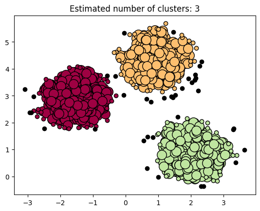

```python
db = DBSCAN(eps=0.3, min_samples=10).fit(X_blobs)
core_samples_mask = np.zeros_like(db.labels_, dtype=bool)
core_samples_mask[db.core_sample_indices_] = True
labels = db.labels_

# Number of clusters in labels, ignoring noise if present.
n_clusters_ = len(set(labels)) - (1 if -1 in labels else 0)
n_noise_ = list(labels).count(-1)

print('Estimated number of clusters: %d' % n_clusters_)
print('Estimated number of noise points: %d' % n_noise_)
print("Homogeneity: %0.3f" % metrics.homogeneity_score(y_blobs, labels))
print("Completeness: %0.3f" % metrics.completeness_score(y_blobs, labels))
print("V-measure: %0.3f" % metrics.v_measure_score(y_blobs, labels))

# Black removed and is used for noise instead.
unique_labels = set(labels)
colors = [plt.cm.Spectral(each)
          for each in np.linspace(0, 1, len(unique_labels))]
for k, col in zip(unique_labels, colors):
    if k == -1:
        # Black used for noise.
        col = [0, 0, 0, 1]

    class_member_mask = (labels == k)

    xy = X_blobs[class_member_mask & core_samples_mask]
    plt.plot(xy[:, 0], xy[:, 1], 'o', markerfacecolor=tuple(col),
             markeredgecolor='k', markersize=14)

    xy = X_blobs[class_member_mask & ~core_samples_mask]
    plt.plot(xy[:, 0], xy[:, 1], 'o', markerfacecolor=tuple(col),
             markeredgecolor='k', markersize=6)

plt.title('Estimated number of clusters: %d' % n_clusters_)
plt.show()
```

[output not shown]

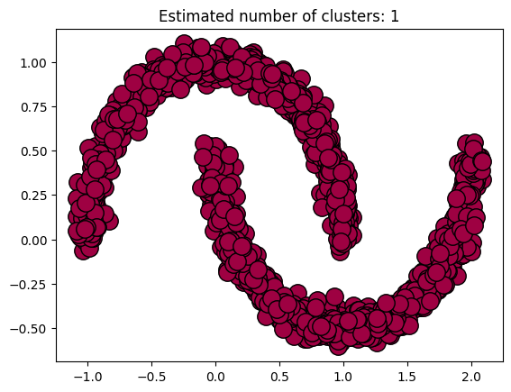

```python
db = DBSCAN(eps=0.3, min_samples=10).fit(noisy_moons[0])
core_samples_mask = np.zeros_like(db.labels_, dtype=bool)
core_samples_mask[db.core_sample_indices_] = True
labels = db.labels_

# Number of clusters in labels, ignoring noise if present.
n_clusters_ = len(set(labels)) - (1 if -1 in labels else 0)
n_noise_ = list(labels).count(-1)

# Black removed and is used for noise instead.
unique_labels = set(labels)
colors = [plt.cm.Spectral(each)
          for each in np.linspace(0, 1, len(unique_labels))]
for k, col in zip(unique_labels, colors):
    if k == -1:
        # Black used for noise.
        col = [0, 0, 0, 1]

    class_member_mask = (labels == k)

    xy = noisy_moons[0][class_member_mask & core_samples_mask]
    plt.plot(xy[:, 0], xy[:, 1], 'o', markerfacecolor=tuple(col),
             markeredgecolor='k', markersize=14)

    xy = noisy_moons[0][class_member_mask & ~core_samples_mask]
    plt.plot(xy[:, 0], xy[:, 1], 'o', markerfacecolor=tuple(col),
             markeredgecolor='k', markersize=6)

plt.title('Estimated number of clusters: %d' % n_clusters_)
plt.show()
```

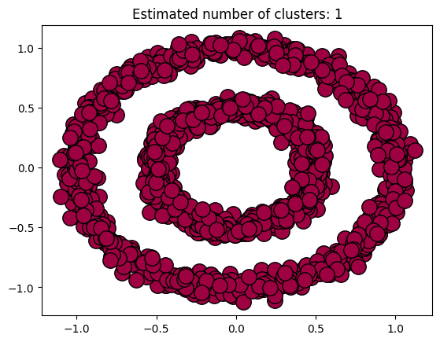

```python
db = DBSCAN(eps=0.3, min_samples=10).fit(noisy_circles[0])

core_samples_mask = np.zeros_like(db.labels_, dtype=bool)
core_samples_mask[db.core_sample_indices_] = True
labels = db.labels_

# Number of clusters in labels, ignoring noise if present.
n_clusters_ = len(set(labels)) - (1 if -1 in labels else 0)
n_noise_ = list(labels).count(-1)

# Black removed and is used for noise instead.
unique_labels = set(labels)
colors = [plt.cm.Spectral(each)
          for each in np.linspace(0, 1, len(unique_labels))]
for k, col in zip(unique_labels, colors):
    if k == -1:
        # Black used for noise.
        col = [0, 0, 0, 1]

    class_member_mask = (labels == k)

    xy = noisy_circles[0][class_member_mask & core_samples_mask]
    plt.plot(xy[:, 0], xy[:, 1], 'o', markerfacecolor=tuple(col),
             markeredgecolor='k', markersize=14)

    xy = noisy_circles[0][class_member_mask & ~core_samples_mask]
    plt.plot(xy[:, 0], xy[:, 1], 'o', markerfacecolor=tuple(col),
             markeredgecolor='k', markersize=6)

plt.title('Estimated number of clusters: %d' % n_clusters_)
plt.show()
```

## Question 2

eps and min_samples are two important parameters for the DBSCAN model. What are those two parameters? Tune the parameters of the model for noisy_circles and noisy_moon dataset to make it separate the clusters perfectly.

- **eps: This parameter is called the epsilon of the algorithm. It, essentially, determines how large the radius of a data point is that decides whether neighboring points will fall into the same "neighborhood" of that original point. If the radius is not large enough then it will cause much of the data to be seen as noise and will not cluster those points. However, if it is too large then some clusters in the data will start to converge with others causing incorrect labeling and increase in the capture of noise within the data.**
- **min_samples: defines the minimum number of samples within a grouping in order for that point to be considered a core point in the data. It works closely with eps in defining these core points as it is dependint on the eps radius, which captures points into it's neighborhood. If there are not enough points in the neighborhood, as defined by the min_samples, then it will not consider the core point and neighborhood as a cluster. The larger min_samples is, the harder it is for a neighborhood to become a cluster and increases the density requirements for a neighborhood to be defined as a cluster.**

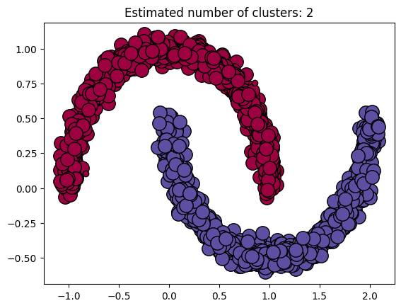

```python
db = DBSCAN(eps=0.1, min_samples=5).fit(noisy_moons[0]) # best defined parameters
core_samples_mask = np.zeros_like(db.labels_, dtype=bool)
core_samples_mask[db.core_sample_indices_] = True
labels = db.labels_

# Number of clusters in labels, ignoring noise if present.
n_clusters_ = len(set(labels)) - (1 if -1 in labels else 0)
n_noise_ = list(labels).count(-1)

# Black removed and is used for noise instead.
unique_labels = set(labels)
colors = [plt.cm.Spectral(each)
          for each in np.linspace(0, 1, len(unique_labels))]
for k, col in zip(unique_labels, colors):
    if k == -1:
        # Black used for noise.
        col = [0, 0, 0, 1]

    class_member_mask = (labels == k)

    xy = noisy_moons[0][class_member_mask & core_samples_mask]
    plt.plot(xy[:, 0], xy[:, 1], 'o', markerfacecolor=tuple(col),
             markeredgecolor='k', markersize=14)

    xy = noisy_moons[0][class_member_mask & ~core_samples_mask]
    plt.plot(xy[:, 0], xy[:, 1], 'o', markerfacecolor=tuple(col),
             markeredgecolor='k', markersize=6)

plt.title('Estimated number of clusters: %d' % n_clusters_)
plt.show()
```

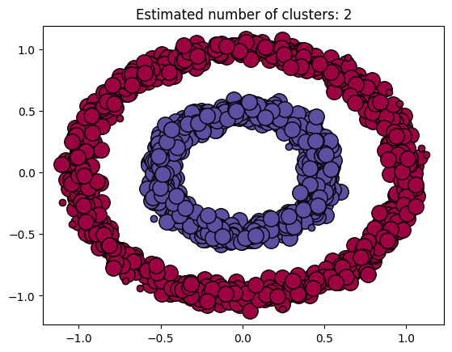

```python
db = DBSCAN(eps=0.1, min_samples=5).fit(noisy_circles[0]) # best defined parameters

core_samples_mask = np.zeros_like(db.labels_, dtype=bool)
core_samples_mask[db.core_sample_indices_] = True
labels = db.labels_

# Number of clusters in labels, ignoring noise if present.
n_clusters_ = len(set(labels)) - (1 if -1 in labels else 0)
n_noise_ = list(labels).count(-1)

# Black removed and is used for noise instead.
unique_labels = set(labels)
colors = [plt.cm.Spectral(each)
          for each in np.linspace(0, 1, len(unique_labels))]
for k, col in zip(unique_labels, colors):
    if k == -1:
        # Black used for noise.
        col = [0, 0, 0, 1]

    class_member_mask = (labels == k)

    xy = noisy_circles[0][class_member_mask & core_samples_mask]
    plt.plot(xy[:, 0], xy[:, 1], 'o', markerfacecolor=tuple(col),
             markeredgecolor='k', markersize=14)

    xy = noisy_circles[0][class_member_mask & ~core_samples_mask]
    plt.plot(xy[:, 0], xy[:, 1], 'o', markerfacecolor=tuple(col),
             markeredgecolor='k', markersize=6)

plt.title('Estimated number of clusters: %d' % n_clusters_)
plt.show()
```

## Mean-Shift Algorithm

Similiar to K-means, Mean shift algorithm locates the centroids of the clusters by shifting the points to density function maxima. Here is the procedure of the algorithm.

1. For each datapoint x ∈ X, find the neighbouring points N(x) of x.
2. For each datapoint x ∈ X, calculate the mean shift m(x).
3. For each datapoint x ∈ X, update x ← m(x).
4. Repeat 1. for n_iterations or until the points are almost not moving or not moving.

```python
import math

def euclid_distance(x, xi):
    return np.sqrt(np.sum((x - xi)**2))

def neighbourhood_points(X, x_centroid, distance = 5):
    eligible_X = []
    for x in X:
        distance_between = euclid_distance(x, x_centroid)
        # print('Evaluating: [%s vs %s] yield dist=%.2f' % (x, x_centroid, distance_between))
        if distance_between <= distance:
            eligible_X.append(x)
    return eligible_X

def gaussian_kernel(distance, bandwidth):
    val = (1/(bandwidth*math.sqrt(2*math.pi))) * np.exp(-0.5*((distance / bandwidth))**2)
    return val
```

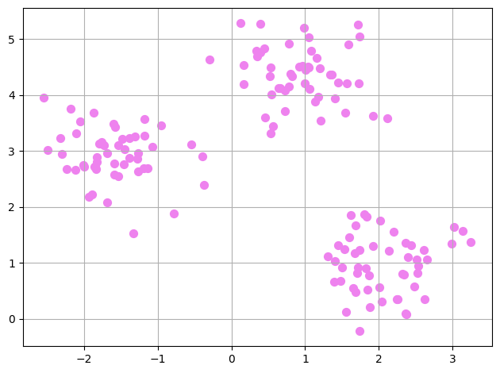

```python
n_samples = 150
X_blobs, y_blobs = make_blobs(n_samples= n_samples,
                  n_features=2,
                  centers=3,
                  cluster_std=0.5,
                  shuffle=True,
                  random_state=0)
plt.scatter(X_blobs[:, 0], X_blobs[:, 1], c='violet', marker='o', s=50)
plt.grid()
plt.tight_layout()
plt.show()
```

```python
original_data = X_blobs
# freeze the original points and make a copy
copy_points = np.copy(original_data)

look_distance = 1  # How far to look for neighbours.
kernel_bandwidth = 8  # Kernel parameter.
# a list to save the history move to do the visualization
past_X = []
n_iteration = 3
for i in range(n_iteration):

    for index, x in enumerate(copy_points):

        # for each datapoint x, find the neighbouring points N(x) of x
        neighbors = neighbourhood_points(copy_points, x, look_distance)
        # calculate the mean shift m(x)

        denominator = 0
        nominator = 0
        for n in neighbors:
            weight = gaussian_kernel(euclid_distance(x, n), kernel_bandwidth)
            nominator += weight * n
            denominator += weight
        new_x = nominator/(denominator+1e-4)
        copy_points[index] = new_x
    past_X.append(np.copy(copy_points))
```

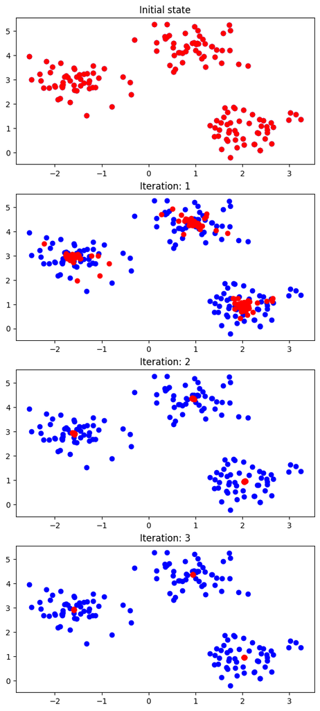

```python
figure = plt.figure(1)
figure.set_size_inches((7, 20))
plt.subplot(n_iteration+2, 1, 1)
plt.title('Initial state')
plt.plot(original_data[:,0], original_data[:,1], 'bo')
plt.plot(original_data[:,0], original_data[:,1], 'ro')

for i in range(n_iteration):
    figure_index = i + 2
    plt.subplot(n_iteration+2, 1, figure_index)
    plt.title('Iteration: %d' % (figure_index - 1))
    plt.plot(original_data[:,0], original_data[:,1], 'bo')
    plt.plot(past_X[i][:,0], past_X[i][:,1], 'ro')
plt.show()
```

## Question 3

look_distance and kernel_bandwidth are two important parameters for mean shift algorithm. kernel_bandwidth simply determines the size of neighborhood over which the density will be computed. look_distance determines the region to look at when searching the surrounding neighbors. Tune these two parameters to make the cluster centroids exactly 3 for the above dataset. What is proper look_distance and kernel_bandwidth in your setting?

```python
original_data = X_blobs
# freeze the original points and make a copy
copy_points = np.copy(original_data)

look_distance = 1  # How far to look for neighbours.
kernel_bandwidth = 1  # Kernel parameter.
# a list to save the history move to do the visualization
past_X = []
n_iteration = 3
for i in range(n_iteration):

    for index, x in enumerate(copy_points):

        # for each datapoint x, find the neighbouring points N(x) of x
        neighbors = neighbourhood_points(copy_points, x, look_distance)
        # calculate the mean shift m(x)

        denominator = 0
        nominator = 0
        for n in neighbors:
            weight = gaussian_kernel(euclid_distance(x, n), kernel_bandwidth)
            nominator += weight * n
            denominator += weight
        new_x = nominator/(denominator+1e-4)
        copy_points[index] = new_x
    past_X.append(np.copy(copy_points))
```

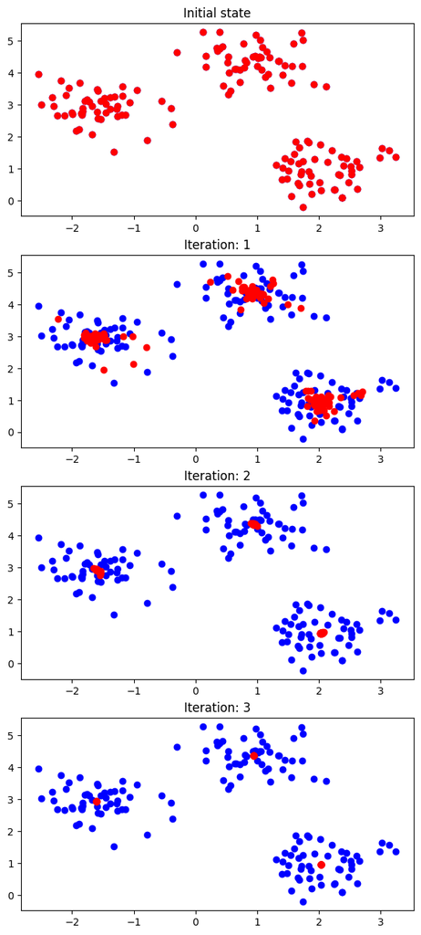

```python
figure = plt.figure(1)
figure.set_size_inches((7, 20))
plt.subplot(n_iteration+2, 1, 1)
plt.title('Initial state')
plt.plot(original_data[:,0], original_data[:,1], 'bo')
plt.plot(original_data[:,0], original_data[:,1], 'ro')

for i in range(n_iteration):
    figure_index = i + 2
    plt.subplot(n_iteration+2, 1, figure_index)
    plt.title('Iteration: %d' % (figure_index - 1))
    plt.plot(original_data[:,0], original_data[:,1], 'bo')
    plt.plot(past_X[i][:,0], past_X[i][:,1], 'ro')
plt.show()
```

**It seems that increasing the look_distance more heavily influences the centroids while kernel_bandwidth does not infulence the centroids as much. However, the currently set values for look_distance and kernel_bandwidth at 1 and 8 distinctly places 3 centroids. I tested for these values at 1 and 1 and received, virtually, the same result**

## Question 4

Apply any of these algorithms to your favorite dataset. Possible applications of clustering algorihtm will include but not be limited to image segmentation and outlier detection.

# Company Clustering Project

### We will use the NYSE data set from Kaggle to determine which companies are essentially under a similar category according to their financials.

```python
import pandas as pd
import numpy as np
import copy
from sklearn.preprocessing import RobustScaler
from sklearn.decomposition import PCA
from sklearn.cluster import KMeans
from sklearn.pipeline import make_pipeline
import matplotlib.pyplot as plt

df = pd.read_csv('fundamentals.csv', index_col=0)
df.head()
```

|  | Ticker Symbol | Period Ending | Accounts Payable | Accounts Receivable | Add'l income/expense items | After Tax ROE | Capital Expenditures | Capital Surplus | Cash Ratio | Cash and Cash Equivalents | ... | Total Current Assets | Total Current Liabilities | Total Equity | Total Liabilities | Total Liabilities & Equity | Total Revenue | Treasury Stock | For Year | Earnings Per Share | Estimated Shares Outstanding |
| --- | --- | --- | --- | --- | --- | --- | --- | --- | --- | --- | --- | --- | --- | --- | --- | --- | --- | --- | --- | --- | --- |
| 0 | AAL | 2012-12-31 | 3.068000e+09 | -222000000.0 | -1.961000e+09 | 23.0 | -1.888000e+09 | 4.695000e+09 | 53.0 | 1.330000e+09 | ... | 7.072000e+09 | 9.011000e+09 | -7.987000e+09 | 2.489100e+10 | 1.690400e+10 | 2.485500e+10 | -367000000.0 | 2012.0 | -5.60 | 3.350000e+08 |
| 1 | AAL | 2013-12-31 | 4.975000e+09 | -93000000.0 | -2.723000e+09 | 67.0 | -3.114000e+09 | 1.059200e+10 | 75.0 | 2.175000e+09 | ... | 1.432300e+10 | 1.380600e+10 | -2.731000e+09 | 4.500900e+10 | 4.227800e+10 | 2.674300e+10 | 0.0 | 2013.0 | -11.25 | 1.630222e+08 |
| 2 | AAL | 2014-12-31 | 4.668000e+09 | -160000000.0 | -1.500000e+08 | 143.0 | -5.311000e+09 | 1.513500e+10 | 60.0 | 1.768000e+09 | ... | 1.175000e+10 | 1.340400e+10 | 2.021000e+09 | 4.120400e+10 | 4.322500e+10 | 4.265000e+10 | 0.0 | 2014.0 | 4.02 | 7.169154e+08 |
| 3 | AAL | 2015-12-31 | 5.102000e+09 | 352000000.0 | -7.080000e+08 | 135.0 | -6.151000e+09 | 1.159100e+10 | 51.0 | 1.085000e+09 | ... | 9.985000e+09 | 1.360500e+10 | 5.635000e+09 | 4.278000e+10 | 4.841500e+10 | 4.099000e+10 | 0.0 | 2015.0 | 11.39 | 6.681299e+08 |
| 4 | AAP | 2012-12-29 | 2.409453e+09 | -89482000.0 | 6.000000e+05 | 32.0 | -2.711820e+08 | 5.202150e+08 | 23.0 | 5.981110e+08 | ... | 3.184200e+09 | 2.559638e+09 | 1.210694e+09 | 3.403120e+09 | 4.613814e+09 | 6.205003e+09 | -27095000.0 | 2012.0 | 5.29 | 7.328355e+07 |

5 rows × 78 columns

```python
df.shape
```

```
(1781, 78)
```

```python
# copy dataset to a new df
df_copy = copy.deepcopy(df)
df_copy.info()
```

[output not shown]

[output cut: 67 more lines]

```python
# only keeping features that report ratios as they are a combination of other features
df_feat_reduced = df_copy[['Cash Ratio', 'Current Ratio', 'Earnings Per Share', 'Quick Ratio', 'Earnings Per Share', 'Profit Margin', 'Pre-Tax ROE', 'Pre-Tax Margin', 'Operating Margin', 'After Tax ROE']]
df_feat_reduced.info()
```

```
<class 'pandas.core.frame.DataFrame'>
Index: 1781 entries, 0 to 1780
Data columns (total 10 columns):
 #   Column              Non-Null Count  Dtype
---  ------              --------------  -----
 0   Cash Ratio          1482 non-null   float64
 1   Current Ratio       1482 non-null   float64
 2   Earnings Per Share  1562 non-null   float64
 3   Quick Ratio         1482 non-null   float64
 4   Earnings Per Share  1562 non-null   float64
 5   Profit Margin       1781 non-null   float64
 6   Pre-Tax ROE         1781 non-null   float64
 7   Pre-Tax Margin      1781 non-null   float64
 8   Operating Margin    1781 non-null   float64
 9   After Tax ROE       1781 non-null   float64
dtypes: float64(10)
memory usage: 153.1 KB
```

```python
df_feat_reduced.describe()
```

|  | Cash Ratio | Current Ratio | Earnings Per Share | Quick Ratio | Earnings Per Share | Profit Margin | Pre-Tax ROE | Pre-Tax Margin | Operating Margin | After Tax ROE |
| --- | --- | --- | --- | --- | --- | --- | --- | --- | --- | --- |
| count | 1482.000000 | 1482.000000 | 1562.000000 | 1482.000000 | 1562.000000 | 1781.000000 | 1781.000000 | 1781.000000 | 1781.000000 | 1781.000000 |
| mean | 74.457490 | 186.771255 | 3.353707 | 146.952767 | 3.353707 | 13.957889 | 59.644582 | 17.754632 | 18.177990 | 43.601348 |
| std | 102.298374 | 128.066801 | 4.695896 | 118.625127 | 4.695896 | 17.559655 | 330.447431 | 21.379605 | 20.504159 | 233.924028 |
| min | 0.000000 | 17.000000 | -61.200000 | 10.000000 | -61.200000 | 0.000000 | 0.000000 | 0.000000 | 0.000000 | 0.000000 |
| 25% | 17.000000 | 109.000000 | 1.590000 | 77.250000 | 1.590000 | 6.000000 | 13.000000 | 8.000000 | 9.000000 | 10.000000 |
| 50% | 41.000000 | 152.000000 | 2.810000 | 115.000000 | 2.810000 | 10.000000 | 22.000000 | 14.000000 | 15.000000 | 16.000000 |
| 75% | 90.000000 | 226.000000 | 4.590000 | 180.000000 | 4.590000 | 17.000000 | 36.000000 | 22.000000 | 23.000000 | 26.000000 |
| max | 1041.000000 | 1197.000000 | 50.090000 | 1197.000000 | 50.090000 | 369.000000 | 9089.000000 | 442.000000 | 437.000000 | 5789.000000 |

```python
# fill null values with 0
df_feat_reduced.fillna(0, inplace=True)
```

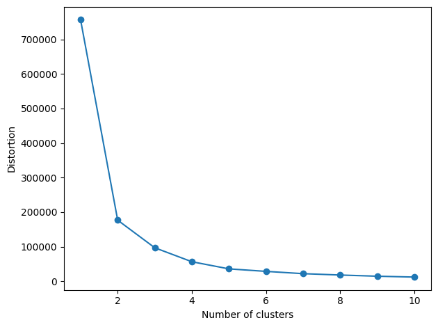

```python
# set up the pipeline and plot distortions to choose k values
def plot_distortions(data):
    distortions = []
    for i in range(1, 11):
        pipe_km = make_pipeline(
            RobustScaler(),
            PCA(n_components=2),
            KMeans(n_clusters=i,
                init='k-means++',
                n_init=10,
                max_iter=300,
                random_state=0)
        )
        pipe_km.fit(data)
        kmeans_step = pipe_km.named_steps['kmeans']
        distortions.append(kmeans_step.inertia_)
        # distortions.append(pipe_km.inertia_)
    plt.plot(range(1, 11), distortions, marker='o')
    plt.xlabel('Number of clusters')
    plt.ylabel('Distortion')
    plt.tight_layout()
    plt.show()

plot_distortions(df_feat_reduced)
```

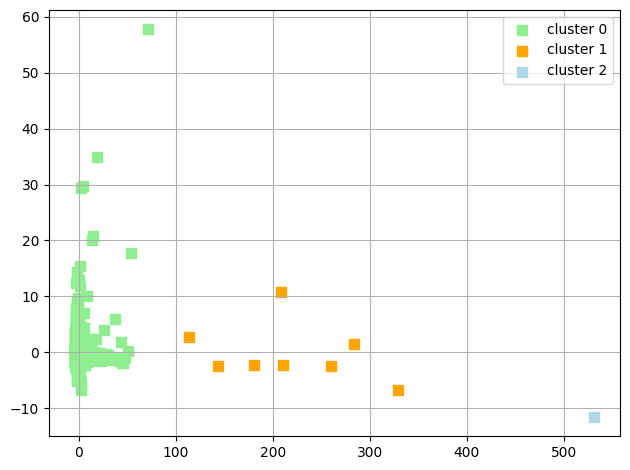

```python
def print_cluster(model, n_clusters, X):
    y_km = model.fit_predict(X)
    color_list = ['lightgreen', 'orange', 'lightblue', 'red', 'yellow', 'brown', 'cyan']
    for i in range(n_clusters):
        plt.scatter(X[y_km == i, 0],
        X[y_km == i, 1],
        s=50,
        c=color_list[i],
        marker='s',
        label='cluster ' + str(i))
    plt.legend()
    plt.grid()
    plt.tight_layout()
    plt.show()

rscaler = RobustScaler()
df_scaled = rscaler.fit_transform(df_feat_reduced)
pca = PCA(n_components=2)
df_pca = pca.fit_transform(df_scaled)

km = KMeans(
    n_clusters=3,
    init='k-means++',
    n_init=10,
    max_iter=300,
    random_state=0
)

print_cluster(km, 3, df_pca)
```

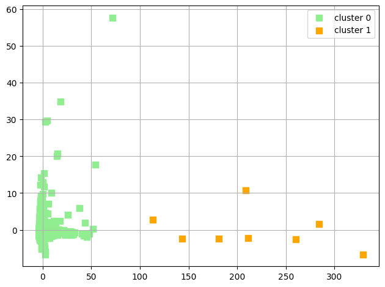

```python
km2 = KMeans(
    n_clusters=2,
    init='k-means++',
    n_init=10,
    max_iter=300,
    random_state=0
)

print_cluster(km, 2, df_pca)
```